# House Prices in New York

Group CC901E2

The University of Sydney

# intro

# Stable Model

## Model stability Plot

- There appears to be dominant models in models of size **two, three, and five** (including the intercept), as demonstrated by one of the circles being substantially larger than the other circles with models of the same size.
- Also, the stepwise model of size 14 is not stable because of their small circle size.
- Finally, it can be found that the simple reversion models is stable, as it is always selected in bootstrap resamples.

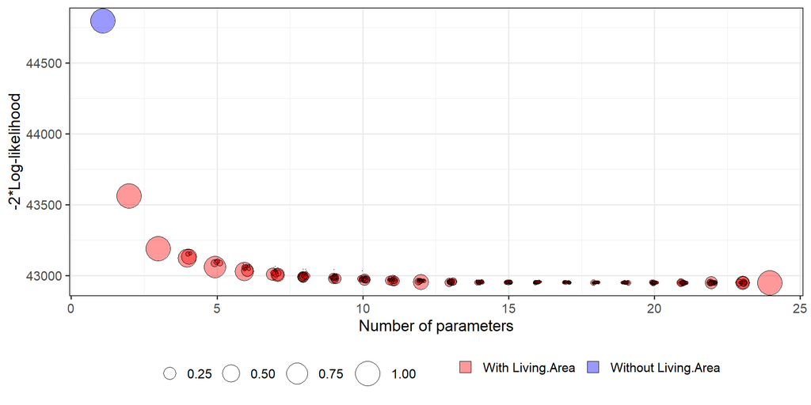

##Conclusion: The $Price \sim Waterfront1 + Land.Value + Living.Area + Bathrooms$ model is selected in 78% of bootstrap resamples, which strikes the balance between accuracy and stability.